# lc2 - On Intercept and Coefficients

Rock Chi

Sunday, October 18, 2015

## Linear Regression

The basic linear model: $Y_i = \beta_0 + \beta_1 X_i + \epsilon_{i}$

Moving Parts of the Model: $\epsilon_{i}$ are assumed iid $N(0, \sigma^2)$

- cumulation of errors from variables missing from the model which we should have modeled

$E[Y_i ~|~ X_i = x_i] = \mu_i = \beta_0 + \beta_1 x_i$

- the expected value of response Y given regressor x is estimated as the value on the line, $\beta_0 + \beta_1 x_i$

$Var(Y_i ~|~ X_i = x_i) = \sigma^2$

- the variance of response Y at any particular point is $\sigma^2$
- this is different from the variance of response Y. It is the variance of Y around the regression line at any point. Thus, lower than the actual variance of Y because some of the variance has been already explained the regressor

## Understanding Regression Coefficients

Intercept Interpretation $E[Y | X = 0] = \beta_0 + \beta_1 \times 0 = \beta_0$

- $\beta_0$, the intercept, is the expected value of the response when predictors are held at 0
- sometimes, predictors held at 0 may not be of interest (ie. heart pressure)

Shifting Regression Variables Away from Intercept 0 $Y_i = \beta_0 + \beta_1 X_i + \epsilon_i = \beta_0 + a \beta_1 + \beta_1 (X_i - a) + \epsilon_i = \tilde \beta_0 + \beta_1 (X_i - a) + \epsilon_i$

- $X$ values are all shifted by a constant of $a$. Intercept is changed, but slope is not
- $a \beta_1$ is added back in changing the intercept
- a possible constant that could be subtracted is the mean

### Simulated Example of Mean Centering

From the Diamond Data, we estimate diamond prices (Singapore Dollars) with carat.

```r
library(UsingR)
data(diamond)

fit1 <- lm(price ~ carat, data=diamond)
coef(fit1)
```

```
## (Intercept)       carat
##   -259.6259   3721.0249
```

From this output, we see when diamond carat is 0, price will be -259! This is not useful for interpretation and inference. Thus, we use mean centering to tease out better information.

```r
fit2 <- lm(price ~ I(carat-mean(carat)), data=diamond)
coef(fit2)
```

```
##            (Intercept) I(carat - mean(carat))
##               500.0833              3721.0249
```

This output expresses the intercept as the expected price of average sized diamonds.

## Coefficient Interpretation

- $\beta_1$ is the expected change in response for a 1 unit change in the predictor

On changing scale/unit of X $X$. $Y_i = \beta_0 + \beta_1 X_i + \epsilon_i = \beta_0 + \frac{\beta_1}{a} (X_i a) + \epsilon_i = \beta_0 + \tilde \beta_1 (X_i a) + \epsilon_i$

- From this equation, we understand that by multiplying regressor $x$ by $a$, we are dividing the coefficients by $a$

### Simulated Example of Unit Changing

Using the diamond dataset again, we predict diamond prices using the same model. However, instead of price change per carat, we would like to see price change per 0.1 carat.

```r
fit3 <- lm(price ~ I(carat*10), data=diamond)
coef(fit3)
```

```
##   (Intercept) I(carat * 10)
##     -259.6259      372.1025
```

## Summary of Scaling and Unit Change

To illustrate the changes from the three transformations:

```
## geom_smooth: method="auto" and size of largest group is <1000, so using loess. Use 'method = x' to change the smoothing method.
```

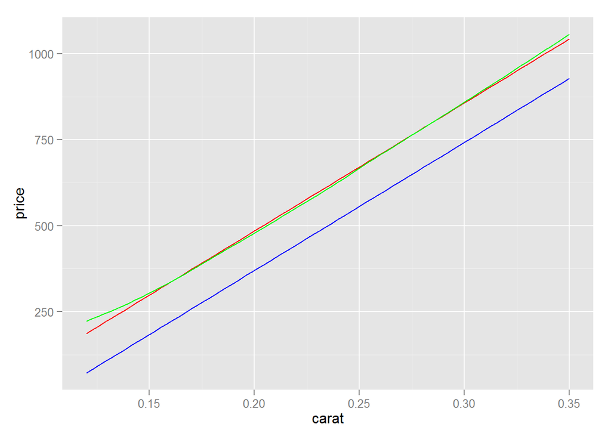

```r
ggplot(diamond, aes(carat, y=price)) +
        stat_smooth(method="lm", formula=y ~ x, se=FALSE, color="red") +
        stat_smooth(method="lm", formula=y ~ I(x-mean(x)), se=FALSE, color="blue") +
        stat_smooth(dmethod="lm", formula=y ~ I(x*10), se=FALSE, color="green")
```

Red line is the non-transformed regression line. X-Intercept is at a negative value.

### Predict Function

The following demonstrates how the predict function work.

```r
newx <- c(0.16, 0.27, 0.34)
#Using the formula (coef 1 == intercept/beta0, coef 2 == beta1)
coef(fit1)[1] + coef(fit1)[2] * newx
```

```
## [1]  335.7381  745.0508 1005.5225
```

```r
#Using prediction function
predict(fit1, newdata=data.frame(carat=newx))
```

```
##         1         2         3
##  335.7381  745.0508 1005.5225
```

As we can see, both are equivalent.